# Projetmachinelearningfraud

```python
import pandas as pd
df = pd.read_csv("C:\\aArthur\\aEcole ESILV\\A4\\Semestre 1\\machine learning\\projet\\archive\\fraudTrain.csv")
print(df.head())
print(df.info())
print(df.describe())
print("Forme du dataset :", df.shape)
```

```
   Unnamed: 0 trans_date_trans_time            cc_num  \
0           0   2019-01-01 00:00:18  2703186189652095
1           1   2019-01-01 00:00:44      630423337322
2           2   2019-01-01 00:00:51    38859492057661
3           3   2019-01-01 00:01:16  3534093764340240
4           4   2019-01-01 00:03:06   375534208663984

                             merchant       category     amt      first  \
0          fraud_Rippin, Kub and Mann       misc_net    4.97   Jennifer
1     fraud_Heller, Gutmann and Zieme    grocery_pos  107.23  Stephanie
2                fraud_Lind-Buckridge  entertainment  220.11     Edward
3  fraud_Kutch, Hermiston and Farrell  gas_transport   45.00     Jeremy
4                 fraud_Keeling-Crist       misc_pos   41.96      Tyler

      last gender                        street  ...      lat      long  \
0    Banks      F                561 Perry Cove  ...  36.0788  -81.1781
1     Gill      F  43039 Riley Greens Suite 393  ...  48.8878 -118.2105
2  Sanchez      M      594 White Dale Suite 530  ...  42.1808 -112.2620
3    White      M   9443 Cynthia Court Apt. 038  ...  46.2306 -112.1138
4   Garcia      M              408 Bradley Rest  ...  38.4207  -79.4629

   city_pop                                job         dob  \
0      3495          Psychologist, counselling  1988-03-09
1       149  Special educational needs teacher  1978-06-21
2      4154        Nature conservation officer  1962-01-19
3      1939                    Patent attorney  1967-01-12
4        99     Dance movement psychotherapist  1986-03-28

                          trans_num   unix_time  merch_lat  merch_long  \
0  0b242abb623afc578575680df30655b9  1325376018  36.011293  -82.048315
1  1f76529f8574734946361c461b024d99  1325376044  49.159047 -118.186462
2  a1a22d70485983eac12b5b88dad1cf95  1325376051  43.150704 -112.154481
3  6b849c168bdad6f867558c3793159a81  1325376076  47.034331 -112.561071
4  a41d7549acf90789359a9aa5346dcb46  1325376186  38.674999  -78.632459

   is_fraud
0         0
1         0
2         0
3         0
```

[output cut: 49 more lines]

```
25%   -9.679800e+01  7.430000e+02  1.338751e+09  3.473357e+01 -9.689728e+01
50%   -8.747690e+01  2.456000e+03  1.349250e+09  3.936568e+01 -8.743839e+01
75%   -8.015800e+01  2.032800e+04  1.359385e+09  4.195716e+01 -8.023680e+01
max   -6.795030e+01  2.906700e+06  1.371817e+09  6.751027e+01 -6.695090e+01

           is_fraud
count  1.296675e+06
mean   5.788652e-03
std    7.586269e-02
min    0.000000e+00
25%    0.000000e+00
50%    0.000000e+00
75%    0.000000e+00
max    1.000000e+00
Forme du dataset : (1296675, 23)
```

Exploration Des Données :

```python
import pandas as pd
import numpy as np
import matplotlib.pyplot as plt
import seaborn as sns

sns.set(style="whitegrid")
plt.rcParams["figure.figsize"] = (10, 5)
# Colonnes temporelles
df['trans_date_trans_time'] = pd.to_datetime(df['trans_date_trans_time'])
if 'hour' not in df.columns:
    df['hour'] = df['trans_date_trans_time'].dt.hour
if 'day' not in df.columns:
    df['day'] = df['trans_date_trans_time'].dt.day
if 'weekday' not in df.columns:
    df['weekday'] = df['trans_date_trans_time'].dt.weekday  # 0 = lundi
if 'month' not in df.columns:
    df['month'] = df['trans_date_trans_time'].dt.month

# Échantillon sûr pour plots lourds
def get_sample(df, n=50000, seed=42):
    return df.sample(n=min(n, len(df)), random_state=seed) if len(df) > n else df.copy()
print("Forme du dataset :", df.shape)
```

```
Forme du dataset : (1296675, 27)
```

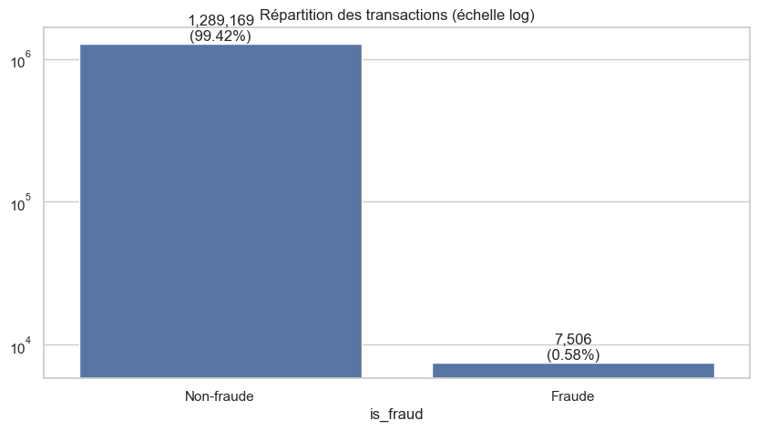

```
Forme du dataset : (1296675, 27)
```

```python
counts = df['is_fraud'].value_counts().sort_index()
props = df['is_fraud'].value_counts(normalize=True).sort_index()

fig, ax = plt.subplots()
sns.barplot(x=counts.index, y=counts.values, ax=ax)
ax.set_yscale('log')
ax.set_xticklabels(['Non-fraude', 'Fraude'])
for i, v in enumerate(counts.values):
    ax.text(i, v, f"{v:,}\n({props.values[i]*100:.2f}%)", ha='center', va='bottom' if v>0 else 'center')
ax.set_title('Répartition des transactions (échelle log)')
plt.show()

print("Forme du dataset :", df.shape)
```

Nous voyons que notre dataset est très déséquilibré... Nous allons donc privilégier les F1-score, et AUC-ROC. Sans ajustement, Notre modèle risque de ne jamais prédire de fraudes... et c'est un problème !

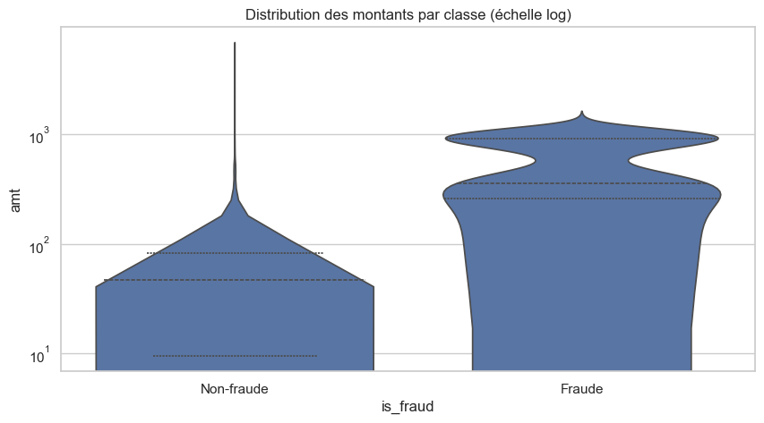

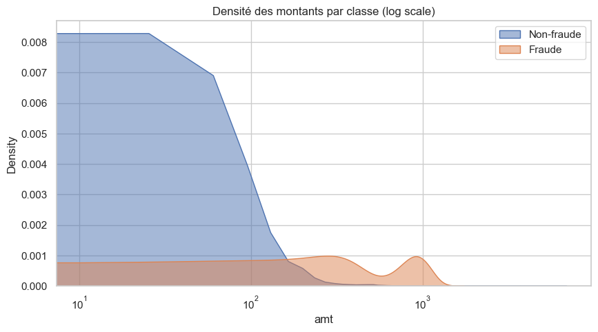

```python
sample = get_sample(df, n=50000)
fig, ax = plt.subplots()
sns.violinplot(data=sample, x='is_fraud', y='amt', inner='quartile', scale='width', ax=ax)
ax.set_yscale('log')
ax.set_xticklabels(['Non-fraude', 'Fraude'])
ax.set_title('Distribution des montants par classe (échelle log)')
plt.show()

# Option : KDE superposée
fig, ax = plt.subplots()
sns.kdeplot(sample.loc[sample['is_fraud']==0, 'amt'], label='Non-fraude', fill=True, common_norm=False, alpha=0.5, ax=ax)
sns.kdeplot(sample.loc[sample['is_fraud']==1, 'amt'], label='Fraude', fill=True, common_norm=False, alpha=0.5, ax=ax)
ax.set_xscale('log')
ax.set_title('Densité des montants par classe (log scale)')
ax.legend()
plt.show()
```

On remarque que les fraudes touchent tous les montants de transactions alors que les non fraudes sont esssentiellementavant 100€

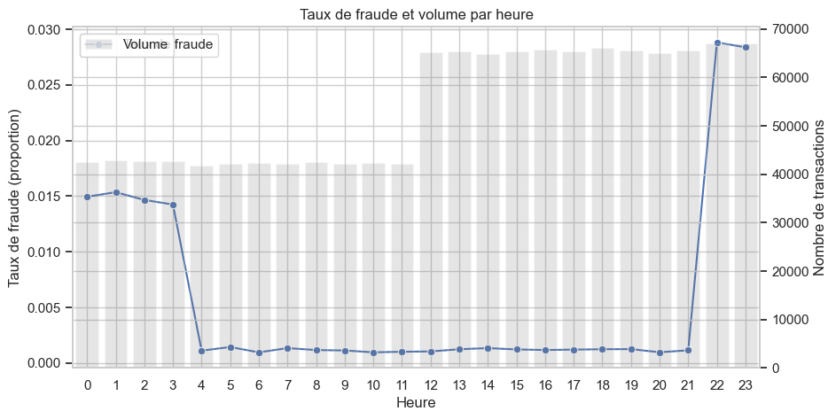

```python
hourly = df.groupby('hour')['is_fraud'].agg(['mean','count']).reset_index().rename(columns={'mean':'fraud_rate','count':'n'})
fig, ax = plt.subplots()
ax2 = ax.twinx()

sns.lineplot(data=hourly, x='hour', y='fraud_rate', marker='o', ax=ax, label='Taux de fraude')
sns.barplot(data=hourly, x='hour', y='n', alpha=0.2, ax=ax2, label='Volume', color='grey')

ax.set_xlabel('Heure')
ax.set_ylabel('Taux de fraude (proportion)')
ax2.set_ylabel('Nombre de transactions')
ax.set_title('Taux de fraude et volume par heure')
ax.set_xticks(range(0,24))
plt.show()
```

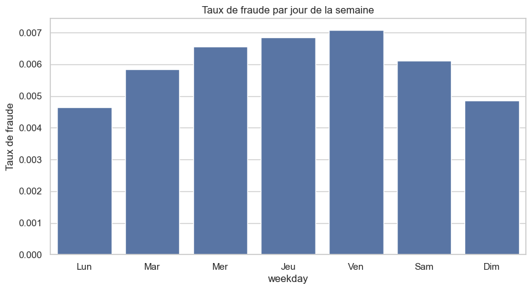

```python
weekday = df.groupby('weekday')['is_fraud'].mean().reindex([0,1,2,3,4,5,6])
fig, ax = plt.subplots()
sns.barplot(x=weekday.index, y=weekday.values, ax=ax)
ax.set_xticklabels(['Lun','Mar','Mer','Jeu','Ven','Sam','Dim'])
ax.set_ylabel('Taux de fraude')
ax.set_title('Taux de fraude par jour de la semaine')
plt.show()
```

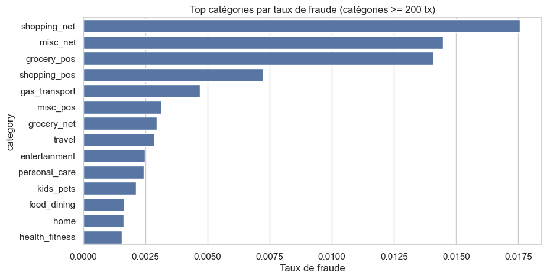

```python
min_tx = 200  # seuil pour éviter bruit statistique
cat_stats = df.groupby('category')['is_fraud'].agg(['mean','count']).rename(columns={'mean':'fraud_rate','count':'n'})
cat_stats_filtered = cat_stats[cat_stats['n'] >= min_tx].sort_values('fraud_rate', ascending=False)
top = cat_stats_filtered.head(15)

fig, ax = plt.subplots()
sns.barplot(x=top['fraud_rate'], y=top.index, ax=ax)
ax.set_xlabel('Taux de fraude')
ax.set_title(f'Top catégories par taux de fraude (catégories >= {min_tx} tx)')
plt.show()
```

Nous voyons que les fraudes touchent principalement le thème du shopping sur internet, les achats divers sur internet, les achats en magasin d'alimentation, les acahts en magasin physique pour le shoppping et les stations services.

```python
import folium
from folium.plugins import MarkerCluster

# Échantillon pour ne pas surcharger la carte
sample_size = 500  # tu peux augmenter si ton ordinateur le supporte
fraud_sample = df[df['is_fraud']==1].sample(n=min(sample_size, df['is_fraud'].sum()), random_state=42)
nonfraud_sample = df[df['is_fraud']==0].sample(n=sample_size, random_state=42)

# Centre de la carte
map_center = [df['lat'].mean(), df['long'].mean()]
m = folium.Map(location=map_center, zoom_start=4)

# Cluster pour les fraudes
fraud_cluster = MarkerCluster(name='Fraudes').add_to(m)
for idx, row in fraud_sample.iterrows():
    folium.CircleMarker(location=[row['lat'], row['long']],
                        radius=3,
                        color='red',
                        fill=True,
                        fill_opacity=0.7).add_to(fraud_cluster)

# Cluster pour les non-fraudes
nonfraud_cluster = MarkerCluster(name='Non-fraudes').add_to(m)
for idx, row in nonfraud_sample.iterrows():
    folium.CircleMarker(location=[row['lat'], row['long']],
                        radius=2,
                        color='blue',
                        fill=True,
                        fill_opacity=0.4).add_to(nonfraud_cluster)

folium.LayerControl().add_to(m)
m
```

Make this Notebook Trusted to load map: File -> Trust Notebook

[interactive chart not shown]

Nous observons que les fraudes sont plus fortes au Nord-Est

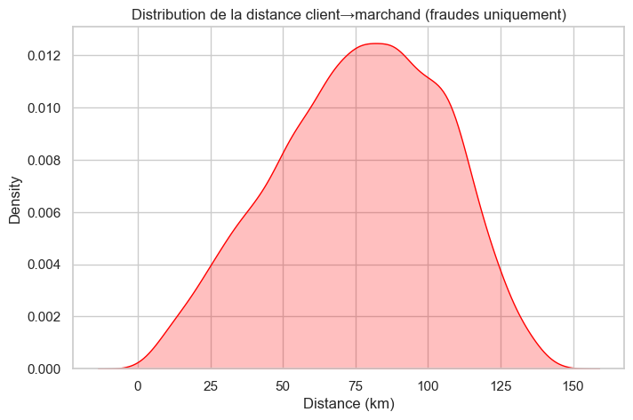

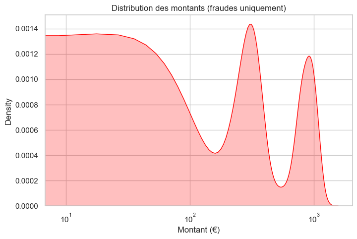

```python
import pandas as pd
import numpy as np
import matplotlib.pyplot as plt
import seaborn as sns

# Assurer que la colonne 'dist_client_merch' existe sinon, problèmes
if {'lat', 'long', 'merch_lat', 'merch_long'}.issubset(df.columns):
    if 'dist_client_merch' not in df.columns:
        def haversine(lat1, lon1, lat2, lon2):
            R = 6371  # rayon Terre en km
            phi1, phi2 = np.radians(lat1), np.radians(lat2)
            dphi = np.radians(lat2 - lat1)
            dlambda = np.radians(lon2 - lon1)
            a = np.sin(dphi/2)**2 + np.cos(phi1)*np.cos(phi2)*np.sin(dlambda/2)**2
            return 2*R*np.arcsin(np.sqrt(a))
        df['dist_client_merch'] = haversine(df['lat'], df['long'], df['merch_lat'], df['merch_long'])
else:
    raise ValueError("Colonnes nécessaires pour calculer la distance manquantes.")

numeric_cols_for_plot = ['dist_client_merch', 'amt']
df_plot = df.copy()
for col in numeric_cols_for_plot:
    if df[col].mean() < 1:  # probablement normalisée
        df_plot[col + '_plot'] = df[col] * df[col].std() + df[col].mean()
    else:
        df_plot[col + '_plot'] = df[col]

# Filtrer uniquement les fraudes
fraud_df = df_plot[df_plot['is_fraud'] == 1].copy()

#  Distribution distance
plt.figure(figsize=(8,5))
sns.kdeplot(data=fraud_df, x='dist_client_merch_plot', fill=True, color='red')
plt.title("Distribution de la distance client→marchand (fraudes uniquement)")
plt.xlabel("Distance (km)")
plt.show()

#  Distribution montant
plt.figure(figsize=(8,5))
sns.kdeplot(data=fraud_df, x='amt_plot', fill=True, color='red')
plt.title("Distribution des montants (fraudes uniquement)")
plt.xlabel("Montant (€)")
plt.xscale('log')  # échelle log pour mieux voir les grosses valeurs
plt.show()
```

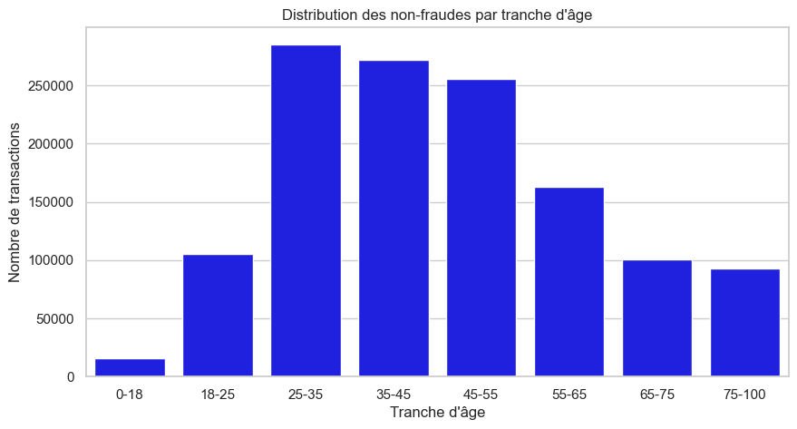

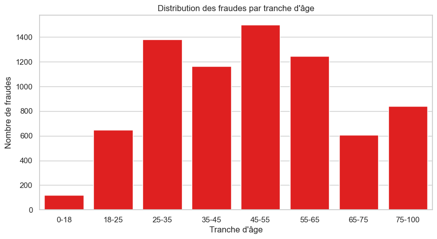

```python
import pandas as pd
import matplotlib.pyplot as plt
import seaborn as sns

# Recharger le CSV original pour avoir dob intact
df_explore = pd.read_csv("C:\\aArthur\\aEcole ESILV\\A4\\Semestre 1\\machine learning\\projet\\archive\\fraudTrain.csv")

# Convertir les dates en datetime
df_explore['trans_date_trans_time'] = pd.to_datetime(df_explore['trans_date_trans_time'])
df_explore['dob'] = pd.to_datetime(df_explore['dob'])

# Calcule de l'âge
df_explore['age'] = (df_explore['trans_date_trans_time'] - df_explore['dob']).dt.days // 365

bins = [0, 18, 25, 35, 45, 55, 65, 75, 100]
labels = ['0-18','18-25','25-35','35-45','45-55','55-65','65-75','75-100']
df_explore['age_group'] = pd.cut(df_explore['age'], bins=bins, labels=labels, right=False)

# Graphique 1 : non-fraudes
plt.figure(figsize=(10,5))
sns.countplot(x='age_group', data=df_explore[df_explore['is_fraud']==0], color='blue')
plt.title("Distribution des non-fraudes par tranche d'âge")
plt.xlabel("Tranche d'âge")
plt.ylabel("Nombre de transactions")
plt.show()

# Graphique 2 : fraudes
plt.figure(figsize=(10,5))
sns.countplot(x='age_group', data=df_explore[df_explore['is_fraud']==1], color='red')
plt.title("Distribution des fraudes par tranche d'âge")
plt.xlabel("Tranche d'âge")
plt.ylabel("Nombre de fraudes")
plt.show()
```

Certaines tranches d'âges sont plus sujets à la fraude

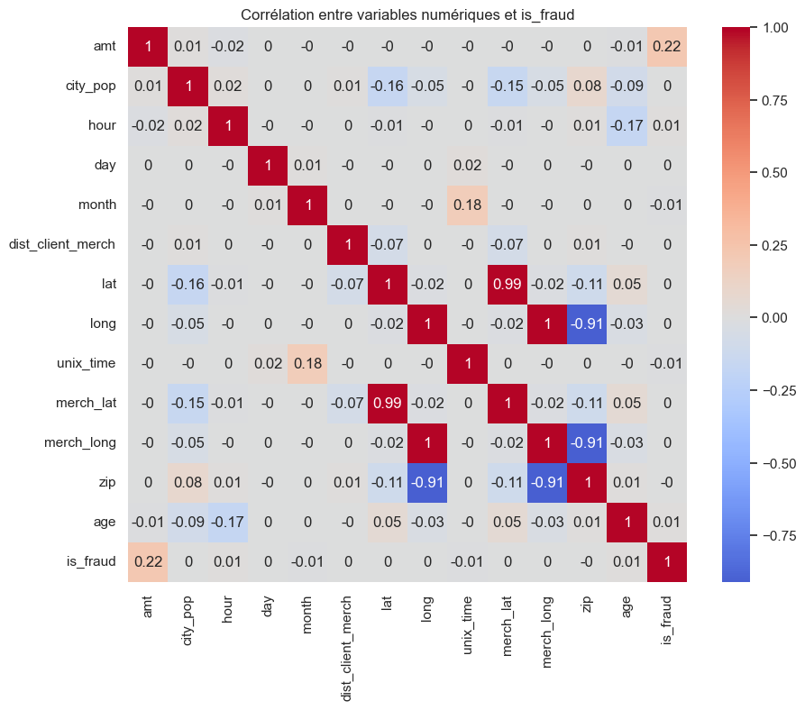

```
Top corrélations (valeur absolue) avec is_fraud :
amt                  0.219404
hour                 0.013799
month                0.012409
age                  0.012343
unix_time            0.005078
day                  0.003848
zip                  0.002162
city_pop             0.002136
lat                  0.001894
merch_lat            0.001741
merch_long           0.001721
long                 0.001721
dist_client_merch    0.000403
Name: is_fraud, dtype: float64
```

```python
# Colonnes numériques existantes
num_cols = ['amt','city_pop','hour','day','month','dist_client_merch',
            'lat','long','unix_time','merch_lat','merch_long','zip']

df['dob'] = pd.to_datetime(df['dob'])
df['age'] = (pd.to_datetime('today') - df['dob']).dt.days // 365
num_cols.append('age')

num_cols = [c for c in num_cols if c in df.columns]

# Calcule de la corrélation
corr = df[num_cols + ['is_fraud']].corr()

# Afficher heatmap lisible
fig, ax = plt.subplots(figsize=(10,8))
sns.heatmap(corr.round(2), annot=True, cmap='coolwarm', center=0, ax=ax)
ax.set_title('Corrélation entre variables numériques et is_fraud')
plt.show()

# Afficher top corr abs avec la target
corr_with_target = corr['is_fraud'].drop('is_fraud').abs().sort_values(ascending=False)
print("Top corrélations (valeur absolue) avec is_fraud :")
print(corr_with_target)
```

On observe que le montant de la transaction (amt) est de loin la variable la plus corrélée avec la fraude, ce qui est cohérent : les fraudes concernent souvent des montants plus élevés. Les autres variables temporelles (hour, month, day) présentent une très faible corrélation, suggérant qu’elles influencent peu la probabilité de fraude de manière directe. Enfin, la distance client→marchand (dist_client_merch) et la population de la ville (city_pop) semblent quasiment indépendantes du caractère frauduleux de la transaction.

Prétraitement :

```python
print("Forme du dataset :", df.shape)
```

```
Forme du dataset : (1296675, 29)
```

```python
import pandas as pd
import numpy as np
from sklearn.preprocessing import StandardScaler, LabelEncoder
```

```python
df['trans_date_trans_time'] = pd.to_datetime(df['trans_date_trans_time'])
df['dob'] = pd.to_datetime(df['dob'], errors='coerce')  # les valeurs incorrectes deviennent NaT

# Vérifier s'il y a des NaT après conversion
print("Nombre de dates de naissance non converties :", df['dob'].isna().sum())

df['age'] = (df['trans_date_trans_time'] - df['dob']).dt.days // 365

df['trans_hour'] = df['trans_date_trans_time'].dt.hour
df['trans_day'] = df['trans_date_trans_time'].dt.day
df['trans_month'] = df['trans_date_trans_time'].dt.month
df['trans_weekday'] = df['trans_date_trans_time'].dt.weekday
df['is_weekend'] = df['trans_weekday'].isin([5,6]).astype(int)
df['is_night'] = df['trans_hour'].isin([0,1,2,3,4,5]).astype(int)
```

```
Nombre de dates de naissance non converties : 0
```

```python
def haversine(lat1, lon1, lat2, lon2):
    R = 6371
    phi1, phi2 = np.radians(lat1), np.radians(lat2)
    dphi = np.radians(lat2 - lat1)
    dlambda = np.radians(lon2 - lon1)
    a = np.sin(dphi/2)**2 + np.cos(phi1)*np.cos(phi2)*np.sin(dlambda/2)**2
    return 2*R*np.arcsin(np.sqrt(a))

df['dist_client_merch'] = haversine(df['lat'], df['long'], df['merch_lat'], df['merch_long'])
df['is_far'] = (df['dist_client_merch'] > df['dist_client_merch'].median()).astype(int)

print("Forme du dataset :", df.shape)
```

```
Forme du dataset : (1296675, 36)
```

```python
# Montant rapporté à la population de la ville (échelle socio-éco)
df['amt_vs_citypop'] = df['amt'] / (df['city_pop'] + 1)

# Transformation log pour réduire l’effet des très gros montants
df['log_amt'] = np.log1p(df['amt'])
print("Forme du dataset :", df.shape)
```

```
Forme du dataset : (1296675, 38)
```

```python
# Supprimer les colonnes inutiles ou non numériques
cols_to_drop = ['Unnamed: 0', 'trans_num', 'cc_num', 'street', 'dob', 'trans_date_trans_time']
df = df.drop(columns=cols_to_drop, errors='ignore')
#nettoyage colonnes inutiles
print("Forme du dataset :", df.shape)
```

```
Forme du dataset : (1296675, 32)
```

```python
# Liste des colonnes catégorielles
categorical_cols = ['merchant', 'category', 'gender', 'city', 'state', 'job']

for col in ['merchant', 'job']:
    top_values = df[col].value_counts().nlargest(30).index
    df[col] = df[col].where(df[col].isin(top_values), other='OTHER')

# Encodage en one-hot
df = pd.get_dummies(df, columns=categorical_cols, drop_first=True)

print("Forme du dataset :", df.shape)
```

```
Forme du dataset : (1296675, 1043)
```

```python
for col in ['age', 'trans_hour', 'trans_day', 'trans_month', 'trans_weekday', 'is_weekend']:
    print(col, col in df.columns)
print("Forme du dataset :", df.shape)
```

```
age True
trans_hour True
trans_day True
trans_month True
trans_weekday True
is_weekend True
Forme du dataset : (1296675, 1043)
```

```python
numeric_cols = ['amt', 'log_amt', 'lat', 'long', 'merch_lat', 'merch_long',
                'city_pop', 'age', 'trans_hour', 'trans_day', 'trans_month',
                'trans_weekday', 'dist_client_merch', 'amt_vs_citypop']

scaler = StandardScaler()
df[numeric_cols] = scaler.fit_transform(df[numeric_cols])
print("Forme du dataset :", df.shape)
```

```
Forme du dataset : (1296675, 1043)
```

```python
print(" Prétraitement terminé")
print("Forme finale du dataset :", df.shape)
print("Colonnes :", list(df.columns)[:15], "...")
print(df.columns)
```

```
 Prétraitement terminé
Forme finale du dataset : (1296675, 1043)
Colonnes : ['amt', 'first', 'last', 'zip', 'lat', 'long', 'city_pop', 'unix_time', 'merch_lat', 'merch_long', 'is_fraud', 'hour', 'day', 'weekday', 'month'] ...
Index(['amt', 'first', 'last', 'zip', 'lat', 'long', 'city_pop', 'unix_time',
       'merch_lat', 'merch_long',
       ...
       'job_Naval architect', 'job_OTHER', 'job_Paramedic', 'job_Podiatrist',
       'job_Scientist, audiological', 'job_Scientist, research (maths)',
       'job_Sub', 'job_Surveyor, land/geomatics', 'job_Systems developer',
       'job_Water engineer'],
      dtype='object', length=1043)
```

Entrainement du modèle :

```python
X = df.drop(columns=['is_fraud'])
y = df['is_fraud']
```

```python
sample_size = 200_000  # nombre de lignes désiré
if len(df) > sample_size:
    df_sample = df.sample(n=sample_size, random_state=42)
    X = df_sample.drop(columns=['is_fraud'])
    y = df_sample['is_fraud']
```

On réduit le nombre de lignes du dataset avant le split train/test pour plusieurs raisons :

1. Mémoire : avec plus d'un million de transactions et beaucoup de colonnes après l'encodage,

le dataset peut devenir trop lourd pour certaines opérations (split, SMOTE, encodage one-hot). 2. Performance : moins de lignes = entraînement plus rapide et tests plus rapides. 3. Stratification : en diminuant le dataset avant le split et en utilisant stratify=y, on conserve la proportion originale de la classe cible (is_fraud) dans les ensembles train et test. Objectif : accélérer le prétraitement et l'entraînement tout en conservant la représentativité des classes.

```python
from sklearn.model_selection import train_test_split

X_train, X_test, y_train, y_test = train_test_split(
    X, y, test_size=0.2, random_state=42, stratify=y
)

print("Forme de X_train :", X_train.shape)
print("Forme de X_test  :", X_test.shape)
print("Distribution de y_train :")
print(y_train.value_counts(normalize=True))
```

```
Forme de X_train : (160000, 1042)
Forme de X_test  : (40000, 1042)
Distribution de y_train :
is_fraud
0    0.994056
1    0.005944
Name: proportion, dtype: float64
```

Utilisation d'une stratification afin de s’assurer que les proportions des différentes classes restent les mêmes dans les ensembles d’entraînement et de test. Dans l'optique que le modèle soit évalué sur un échantillon représentatif de toutes les classes et ne soit pas trop impacté par le déséquilibre.

```python
from sklearn.linear_model import LogisticRegression
from sklearn.metrics import classification_report, roc_auc_score
from imblearn.over_sampling import SMOTE

# Colonnes numériques
numeric_cols = ['amt', 'lat', 'long', 'merch_lat', 'merch_long', 'city_pop',
                'age', 'trans_hour', 'trans_day', 'trans_month', 'trans_weekday',
                'dist_client_merch']

# Sélection des colonnes numériques pour X_train et X_test
X_train_num = X_train[numeric_cols]
X_test_num = X_test[numeric_cols]

'''
# Appliquer SMOTE sur X_train_num
# Nous avons rééquilibrer le dataset grâce à SMOTE
smote = SMOTE(random_state=42)
X_train_res, y_train_res = smote.fit_resample(X_train_num, y_train)

print("Avant SMOTE :", y_train.value_counts())
print("Après SMOTE :", y_train_res.value_counts())
'''



# Appliquer SMOTE avec un ratio moins extrême : la minoritaire = 10% de la majoritaire
smote = SMOTE(
    random_state=42,
    sampling_strategy=0.1   # la clé
)

X_train_res, y_train_res = smote.fit_resample(X_train_num, y_train)

print("Avant SMOTE :")
print(y_train.value_counts())
print("\nAprès SMOTE (sampling_strategy=0.1) :")
print(y_train_res.value_counts())
```

```
Avant SMOTE :
is_fraud
0    159049
1       951
Name: count, dtype: int64

Après SMOTE (sampling_strategy=0.1) :
is_fraud
0    159049
1     15904
Name: count, dtype: int64
```

Après un échange avec Mr Ortega, nous avons remarqué que notre smote initiale était trop violent et ne représentait donc pas la réalité.

Nous avons rééquilibrer le dataset

```python
from sklearn.preprocessing import StandardScaler

numeric_cols = ['amt', 'lat', 'long', 'merch_lat', 'merch_long', 'city_pop',
                'age', 'trans_hour', 'trans_day', 'trans_month', 'trans_weekday',
                'dist_client_merch']

scaler = StandardScaler()
X_train_res[numeric_cols] = scaler.fit_transform(X_train_res[numeric_cols])
X_test[numeric_cols] = scaler.transform(X_test[numeric_cols])
```

On met toutes les colonnes numériques sur la même échelle avec un StandardScaler, pour que les variables aient une moyenne nulle et un écart-type de 1, ce qui aide le modèle à mieux apprendre. On ajuste sur le train (fit_transform) et on applique sur le test (transform).

```python
from sklearn.ensemble import RandomForestClassifier
from sklearn.metrics import classification_report, roc_auc_score, confusion_matrix

# On réutilise les mêmes colonnes numériques que pour le scaling et les autres modèles
numeric_cols = ['amt', 'lat', 'long', 'merch_lat', 'merch_long', 'city_pop',
                'age', 'trans_hour', 'trans_day', 'trans_month', 'trans_weekday',
                'dist_client_merch']

# On entraîne RandomForest sur le jeu de données rééquilibré (SMOTE) et standardisé
X_train_num = X_train_res[numeric_cols]
X_test_num = X_test[numeric_cols]

rf = RandomForestClassifier(
    n_estimators=100,
    random_state=42,
    class_weight='balanced',
    n_jobs=-1
)

rf.fit(X_train_num, y_train_res)
y_pred = rf.predict(X_test_num)
y_proba = rf.predict_proba(X_test_num)[:, 1]

print("=== RandomForestClassifier ===")
print(classification_report(y_test, y_pred))
print("AUC ROC :", roc_auc_score(y_test, y_proba))
```

```
=== RandomForestClassifier ===
              precision    recall  f1-score   support

           0       1.00      1.00      1.00     39762
           1       0.62      0.53      0.57       238

    accuracy                           1.00     40000
   macro avg       0.81      0.77      0.79     40000
weighted avg       0.99      1.00      1.00     40000

AUC ROC : 0.9744762323218105
```

Le Random Forest est un ensemble d’arbres de décision qui vote pour prédire si une transaction est frauduleuse. Il est robuste aux variables corrélées et gère bien les grands datasets. On évalue les performances avec le rapport de classification et l’AUC ROC.

```python
from sklearn.linear_model import LogisticRegression
from sklearn.metrics import (
    classification_report, roc_auc_score, average_precision_score,
    confusion_matrix, recall_score, precision_score, f1_score,
    balanced_accuracy_score
)

lr = LogisticRegression(max_iter=1000, random_state=42)
lr.fit(X_train_res, y_train_res)

X_test_aligned = X_test[numeric_cols]  # afin que le modèle voie exactement les mêmes features que celles sur lesquelles il a été entraîné

y_pred = lr.predict(X_test_aligned)
y_proba = lr.predict_proba(X_test_aligned)[:, 1]

# Évaluation générale
print("Classification Report :\n", classification_report(y_test, y_pred))
print("AUC ROC :", roc_auc_score(y_test, y_proba))

# Precision-Recall AUC (plus pertinent pour classes déséquilibrées)
pr_auc = average_precision_score(y_test, y_proba)
print("Precision-Recall AUC :", pr_auc)

# Matrice de confusion
cm = confusion_matrix(y_test, y_pred)
print("Matrice de confusion :\n", cm)

# Metrics pour la classe minoritaire (1)
recall_1 = recall_score(y_test, y_pred, pos_label=1)
precision_1 = precision_score(y_test, y_pred, pos_label=1)
f1_1 = f1_score(y_test, y_pred, pos_label=1)
print(f"Classe 1 → Recall: {recall_1:.2f}, Precision: {precision_1:.2f}, F1-score: {f1_1:.2f}")

# Balanced Accuracy
bal_acc = balanced_accuracy_score(y_test, y_pred)
print("Balanced Accuracy :", bal_acc)
```

```
Classification Report :
               precision    recall  f1-score   support

           0       1.00      0.99      0.99     39762
           1       0.29      0.51      0.37       238

    accuracy                           0.99     40000
   macro avg       0.65      0.75      0.68     40000
weighted avg       0.99      0.99      0.99     40000

AUC ROC : 0.8610545772556798
Precision-Recall AUC : 0.20398744051613116
Matrice de confusion :
 [[39469   293]
 [  116   122]]
Classe 1 → Recall: 0.51, Precision: 0.29, F1-score: 0.37
Balanced Accuracy : 0.7526180986956423
```

```python
import xgboost as xgb

# Créer le modèle XGBoost
xgb_model = xgb.XGBClassifier(
    n_estimators=100,
    learning_rate=0.1,
    random_state=42,
    use_label_encoder=False,
    eval_metric='logloss'
)

# Entraînement sur le jeu de données SMOTE
xgb_model.fit(X_train_res, y_train_res)

X_test_aligned = X_test[numeric_cols]

# Prédictions
y_pred = xgb_model.predict(X_test_aligned)
y_proba = xgb_model.predict_proba(X_test_aligned)[:, 1]

# Évaluation générale
print("Classification Report :\n", classification_report(y_test, y_pred))
print("AUC ROC :", roc_auc_score(y_test, y_proba))

# Precision-Recall AUC (plus pertinent pour classes déséquilibrées)
pr_auc = average_precision_score(y_test, y_proba)
print("Precision-Recall AUC :", pr_auc)

# Matrice de confusion
cm = confusion_matrix(y_test, y_pred)
print("Matrice de confusion :\n", cm)

# Metrics pour la classe minoritaire (1)
recall_1 = recall_score(y_test, y_pred, pos_label=1)
precision_1 = precision_score(y_test, y_pred, pos_label=1)
f1_1 = f1_score(y_test, y_pred, pos_label=1)
print(f"Classe 1 → Recall: {recall_1:.2f}, Precision: {precision_1:.2f}, F1-score: {f1_1:.2f}")

# Balanced Accuracy
bal_acc = balanced_accuracy_score(y_test, y_pred)
print("Balanced Accuracy :", bal_acc)
```

```
Classification Report :
               precision    recall  f1-score   support

           0       1.00      1.00      1.00     39762
           1       0.62      0.60      0.61       238

    accuracy                           1.00     40000
   macro avg       0.81      0.80      0.80     40000
weighted avg       1.00      1.00      1.00     40000

AUC ROC : 0.9794949064581318
Precision-Recall AUC : 0.6385790831707109
Matrice de confusion :
 [[39675    87]
 [   96   142]]
Classe 1 → Recall: 0.60, Precision: 0.62, F1-score: 0.61
Balanced Accuracy : 0.7972253183754262
```

```python
from sklearn.neighbors import KNeighborsClassifier

# Créer et entraîner le modèle KNN
knn = KNeighborsClassifier(n_neighbors=5)
knn.fit(X_train_res, y_train_res)

X_test_aligned = X_test[numeric_cols]

# Prédictions
y_pred = knn.predict(X_test_aligned)
y_proba = knn.predict_proba(X_test_aligned)[:, 1]

# Évaluation générale
print("Classification Report :\n", classification_report(y_test, y_pred))
print("AUC ROC :", roc_auc_score(y_test, y_proba))

# Precision-Recall AUC (plus pertinent pour classes déséquilibrées)
pr_auc = average_precision_score(y_test, y_proba)
print("Precision-Recall AUC :", pr_auc)

# Matrice de confusion
cm = confusion_matrix(y_test, y_pred)
print("Matrice de confusion :\n", cm)

# Metrics pour la classe minoritaire (1)
recall_1 = recall_score(y_test, y_pred, pos_label=1)
precision_1 = precision_score(y_test, y_pred, pos_label=1)
f1_1 = f1_score(y_test, y_pred, pos_label=1)
print(f"Classe 1 → Recall: {recall_1:.2f}, Precision: {precision_1:.2f}, F1-score: {f1_1:.2f}")

# Balanced Accuracy
bal_acc = balanced_accuracy_score(y_test, y_pred)
print("Balanced Accuracy :", bal_acc)
```

```
Classification Report :
               precision    recall  f1-score   support

           0       1.00      0.99      0.99     39762
           1       0.22      0.61      0.32       238

    accuracy                           0.98     40000
   macro avg       0.61      0.80      0.66     40000
weighted avg       0.99      0.98      0.99     40000

AUC ROC : 0.8272406744499521
Precision-Recall AUC : 0.246943248490825
Matrice de confusion :
 [[39241   521]
 [   93   145]]
Classe 1 → Recall: 0.61, Precision: 0.22, F1-score: 0.32
Balanced Accuracy : 0.7980703674256786
```

KNN prédit la classe d’une transaction en regardant les transactions les plus proches dans l’espace des features. Il est simple et non paramétrique, mais peut être lent sur de grands datasets. L’AUC ROC mesure sa capacité à détecter les fraudes correctement.

```python
from sklearn.svm import LinearSVC
from sklearn.metrics import (
    classification_report, confusion_matrix,
    recall_score, precision_score, f1_score, balanced_accuracy_score
)

print("Entraînement du LinearSVC (SVM linéaire)...")

# Entraînement SUPER RAPIDE
lin_svm = LinearSVC(
    random_state=42,
    max_iter=5000,
    tol=1e-3        # tolérance raisonnable
)

lin_svm.fit(X_train_res, y_train_res)

# Prédictions
X_test_aligned = X_test[numeric_cols]
y_pred = lin_svm.predict(X_test_aligned)

# Scores
print("Classification Report :\n", classification_report(y_test, y_pred))

# Matrice de confusion
cm = confusion_matrix(y_test, y_pred)
print("Matrice de confusion :\n", cm)

# Metrics pour la classe fraude
recall_1 = recall_score(y_test, y_pred, pos_label=1)
precision_1 = precision_score(y_test, y_pred, pos_label=1)
f1_1 = f1_score(y_test, y_pred, pos_label=1)
bal_acc = balanced_accuracy_score(y_test, y_pred)

print(f"Classe 1 → Recall: {recall_1:.2f}, Precision: {precision_1:.2f}, F1-score: {f1_1:.2f}")
print("Balanced Accuracy :", bal_acc)
```

```
Entraînement du LinearSVC (SVM linéaire)...
Classification Report :
               precision    recall  f1-score   support

           0       1.00      0.99      1.00     39762
           1       0.36      0.49      0.42       238

    accuracy                           0.99     40000
   macro avg       0.68      0.74      0.71     40000
weighted avg       0.99      0.99      0.99     40000

Matrice de confusion :
 [[39557   205]
 [  121   117]]
Classe 1 → Recall: 0.49, Precision: 0.36, F1-score: 0.42
Balanced Accuracy : 0.7432204811908164
```

Le SVM cherche la meilleure frontière qui sépare les fraudes des non-fraudes dans l’espace des features. Il peut utiliser des noyaux pour gérer les relations non linéaires. L’AUC ROC indique la qualité de cette séparation.

```python
from imblearn.ensemble import BalancedRandomForestClassifier
from sklearn.metrics import (
    classification_report, confusion_matrix,
    recall_score, precision_score, f1_score, balanced_accuracy_score
)

print("Entraînement du BalancedRandomForest...")

brf = BalancedRandomForestClassifier(
    n_estimators=300,
    random_state=42,
    n_jobs=-1,
    sampling_strategy='all',
    replacement=True,
    bootstrap=False
)

brf.fit(X_train_res, y_train_res)

# Prédictions
X_test_aligned = X_test[numeric_cols]
y_pred = brf.predict(X_test_aligned)

# Scores
print("Classification Report :\n", classification_report(y_test, y_pred))

# Matrice de confusion
cm = confusion_matrix(y_test, y_pred)
print("Matrice de confusion :\n", cm)

# Metrics pour la classe fraude
recall_1 = recall_score(y_test, y_pred, pos_label=1)
precision_1 = precision_score(y_test, y_pred, pos_label=1)
f1_1 = f1_score(y_test, y_pred, pos_label=1)
bal_acc = balanced_accuracy_score(y_test, y_pred)

print(f"Classe 1 → Recall: {recall_1:.2f}, Precision: {precision_1:.2f}, F1-score: {f1_1:.2f}")
print("Balanced Accuracy :", bal_acc)
```

```
Entraînement du BalancedRandomForest...
Classification Report :
               precision    recall  f1-score   support

           0       1.00      0.99      0.99     39762
           1       0.32      0.75      0.45       238

    accuracy                           0.99     40000
   macro avg       0.66      0.87      0.72     40000
weighted avg       0.99      0.99      0.99     40000

Matrice de confusion :
 [[39390   372]
 [   59   179]]
Classe 1 → Recall: 0.75, Precision: 0.32, F1-score: 0.45
Balanced Accuracy : 0.8713725870610807
```

```python
from imblearn.ensemble import EasyEnsembleClassifier
from sklearn.metrics import (
    classification_report, confusion_matrix,
    recall_score, precision_score, f1_score, balanced_accuracy_score
)
print("Entraînement du EasyEnsembleClassifier...")

# On entraîne sur les données SMOTÉES (comme BalancedRF)
eec = EasyEnsembleClassifier(
    n_estimators=10,
    random_state=42,
    n_jobs=-1
)

eec.fit(X_train_res, y_train_res)

# Prédictions
X_test_aligned = X_test[numeric_cols]
y_pred_eec = eec.predict(X_test_aligned)

# Rapport
print("Classification Report :\n", classification_report(y_test, y_pred_eec))

# Matrice de confusion
cm = confusion_matrix(y_test, y_pred_eec)
print("Matrice de confusion :\n", cm)

# Metrics fraude
recall_1 = recall_score(y_test, y_pred_eec, pos_label=1)
precision_1 = precision_score(y_test, y_pred_eec, pos_label=1)
f1_1 = f1_score(y_test, y_pred_eec, pos_label=1)
bal_acc = balanced_accuracy_score(y_test, y_pred_eec)

print(f"Classe 1 → Recall: {recall_1:.2f}, Precision: {precision_1:.2f}, F1-score: {f1_1:.2f}")
print("Balanced Accuracy :", bal_acc)
```

```
Entraînement du EasyEnsembleClassifier...
Classification Report :
               precision    recall  f1-score   support

           0       1.00      0.95      0.97     39762
           1       0.09      0.92      0.17       238

    accuracy                           0.95     40000
   macro avg       0.55      0.93      0.57     40000
weighted avg       0.99      0.95      0.97     40000

Matrice de confusion :
 [[37591  2171]
 [   18   220]]
Classe 1 → Recall: 0.92, Precision: 0.09, F1-score: 0.17
Balanced Accuracy : 0.9348849393386448
```

```python
from imblearn.ensemble import RUSBoostClassifier
from sklearn.metrics import (
    classification_report, confusion_matrix,
    recall_score, precision_score, f1_score, balanced_accuracy_score
)

print("Entraînement du RUSBoostClassifier...")

# On entraîne RUSBoost sur les données SMOTÉES
rusboost = RUSBoostClassifier(
    n_estimators=200,
    learning_rate=0.1,
    random_state=42
)

rusboost.fit(X_train_res, y_train_res)

# Prédiction
X_test_aligned = X_test[numeric_cols]
y_pred_rus = rusboost.predict(X_test_aligned)

# Rapport
print("Classification Report :\n", classification_report(y_test, y_pred_rus))

# Matrice de confusion
cm = confusion_matrix(y_test, y_pred_rus)
print("Matrice de confusion :\n", cm)

# Metrics fraude
recall_1 = recall_score(y_test, y_pred_rus, pos_label=1)
precision_1 = precision_score(y_test, y_pred_rus, pos_label=1)
f1_1 = f1_score(y_test, y_pred_rus, pos_label=1)
bal_acc = balanced_accuracy_score(y_test, y_pred_rus)

print(f"Classe 1 → Recall: {recall_1:.2f}, Precision: {precision_1:.2f}, F1-score: {f1_1:.2f}")
print("Balanced Accuracy :", bal_acc)
```

```
Entraînement du RUSBoostClassifier...
Classification Report :
               precision    recall  f1-score   support

           0       1.00      0.95      0.97     39762
           1       0.10      0.93      0.17       238

    accuracy                           0.95     40000
   macro avg       0.55      0.94      0.57     40000
weighted avg       0.99      0.95      0.97     40000

Matrice de confusion :
 [[37684  2078]
 [   17   221]]
Classe 1 → Recall: 0.93, Precision: 0.10, F1-score: 0.17
Balanced Accuracy : 0.9381552379515259
```

```python
import numpy as np
import pandas as pd
from sklearn.metrics import (
    roc_auc_score, average_precision_score,
    confusion_matrix, recall_score, precision_score, f1_score,
    balanced_accuracy_score, classification_report
)

results = {}

def eval_model(name, model, X, y_true):
    y_pred = model.predict(X)

    rec_1   = recall_score(y_true, y_pred, pos_label=1)
    prec_1  = precision_score(y_true, y_pred, pos_label=1, zero_division=0)
    f1_1    = f1_score(y_true, y_pred, pos_label=1)
    bal_acc = balanced_accuracy_score(y_true, y_pred)

    roc_auc = np.nan
    pr_auc  = np.nan

    if hasattr(model, "predict_proba"):
        y_proba = model.predict_proba(X)[:, 1]
        roc_auc = roc_auc_score(y_true, y_proba)
        pr_auc  = average_precision_score(y_true, y_proba)
    elif hasattr(model, "decision_function"):
        scores = model.decision_function(X)
        scores = (scores - scores.min()) / (scores.max() - scores.min() + 1e-12)
        roc_auc = roc_auc_score(y_true, scores)
        pr_auc  = average_precision_score(y_true, scores)

    results[name] = {
        "recall_fraud": rec_1,
        "precision_fraud": prec_1,
        "f1_fraud": f1_1,
        "balanced_accuracy": bal_acc,
        "roc_auc": roc_auc,
        "pr_auc": pr_auc
    }

    print(f"\n=== {name} ===")
    print(classification_report(y_true, y_pred))
    print("Matrice de confusion :\n", confusion_matrix(y_true, y_pred))
    print(f"Classe 1 → Recall: {rec_1:.3f}, Precision: {prec_1:.3f}, F1: {f1_1:.3f}")
    print(f"Balanced accuracy: {bal_acc:.3f}")
    print(f"AUC ROC: {roc_auc:.3f}, AUC PR: {pr_auc:.3f}")


X_test_num = X_test[numeric_cols]

models_to_eval = {
    "LogisticRegression": lr,
    "RandomForest": rf,
    "XGBoost": xgb_model,
    "KNN": knn,
    "LinearSVM": lin_svm,
    "BalancedRF": brf,
    "EasyEnsemble": eec,
    "RUSBoost": rusboost
}

for name, model in models_to_eval.items():
    try:
        eval_model(name, model, X_test_num, y_test)
    except Exception as e:
        print(f" {name} non évalué :", e)

results_df = pd.DataFrame(results).T
results_df
```

```
=== LogisticRegression ===
              precision    recall  f1-score   support

           0       1.00      0.99      0.99     39762
           1       0.29      0.51      0.37       238

    accuracy                           0.99     40000
   macro avg       0.65      0.75      0.68     40000
weighted avg       0.99      0.99      0.99     40000

Matrice de confusion :
 [[39469   293]
 [  116   122]]
Classe 1 → Recall: 0.513, Precision: 0.294, F1: 0.374
Balanced accuracy: 0.753
AUC ROC: 0.861, AUC PR: 0.204

=== RandomForest ===
              precision    recall  f1-score   support

           0       1.00      1.00      1.00     39762
           1       0.62      0.53      0.57       238

    accuracy                           1.00     40000
   macro avg       0.81      0.77      0.79     40000
weighted avg       0.99      1.00      1.00     40000

Matrice de confusion :
 [[39685    77]
 [  111   127]]
Classe 1 → Recall: 0.534, Precision: 0.623, F1: 0.575
Balanced accuracy: 0.766
AUC ROC: 0.974, AUC PR: 0.598

=== XGBoost ===
              precision    recall  f1-score   support

           0       1.00      1.00      1.00     39762
           1       0.62      0.60      0.61       238

```

[output cut: 80 more lines]

```
              precision    recall  f1-score   support

           0       1.00      0.95      0.97     39762
           1       0.10      0.93      0.17       238

    accuracy                           0.95     40000
   macro avg       0.55      0.94      0.57     40000
weighted avg       0.99      0.95      0.97     40000

Matrice de confusion :
 [[37684  2078]
 [   17   221]]
Classe 1 → Recall: 0.929, Precision: 0.096, F1: 0.174
Balanced accuracy: 0.938
AUC ROC: 0.978, AUC PR: 0.514
```

|  | recall_fraud | precision_fraud | f1_fraud | balanced_accuracy | roc_auc | pr_auc |
| --- | --- | --- | --- | --- | --- | --- |
| LogisticRegression | 0.512605 | 0.293976 | 0.373660 | 0.752618 | 0.861055 | 0.203987 |
| RandomForest | 0.533613 | 0.622549 | 0.574661 | 0.765838 | 0.974476 | 0.598460 |
| XGBoost | 0.596639 | 0.620087 | 0.608137 | 0.797225 | 0.979495 | 0.638579 |
| KNN | 0.609244 | 0.217718 | 0.320796 | 0.798070 | 0.827241 | 0.246943 |
| LinearSVM | 0.491597 | 0.363354 | 0.417857 | 0.743220 | 0.848658 | 0.204511 |
| BalancedRF | 0.752101 | 0.324864 | 0.453739 | 0.871373 | 0.980629 | 0.573216 |
| EasyEnsemble | 0.924370 | 0.092012 | 0.167364 | 0.934885 | 0.977591 | 0.477056 |
| RUSBoost | 0.928571 | 0.096129 | 0.174222 | 0.938155 | 0.977595 | 0.514234 |

|  | recall_fraud | precision_fraud | f1_fraud | balanced_accuracy | roc_auc | pr_auc |
| --- | --- | --- | --- | --- | --- | --- |
| LogisticRegression | 0.512605 | 0.293976 | 0.373660 | 0.752618 | 0.861055 | 0.203987 |
| RandomForest | 0.533613 | 0.622549 | 0.574661 | 0.765838 | 0.974476 | 0.598460 |
| XGBoost | 0.596639 | 0.620087 | 0.608137 | 0.797225 | 0.979495 | 0.638579 |
| KNN | 0.609244 | 0.217718 | 0.320796 | 0.798070 | 0.827241 | 0.246943 |
| LinearSVM | 0.491597 | 0.363354 | 0.417857 | 0.743220 | 0.848658 | 0.204511 |
| BalancedRF | 0.752101 | 0.324864 | 0.453739 | 0.871373 | 0.980629 | 0.573216 |
| EasyEnsemble | 0.924370 | 0.092012 | 0.167364 | 0.934885 | 0.977591 | 0.477056 |
| RUSBoost | 0.928571 | 0.096129 | 0.174222 | 0.938155 | 0.977595 | 0.514234 |

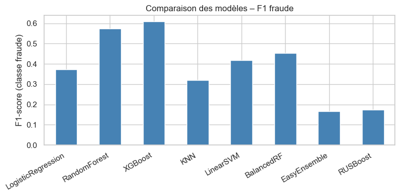

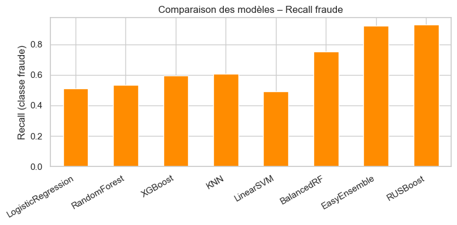

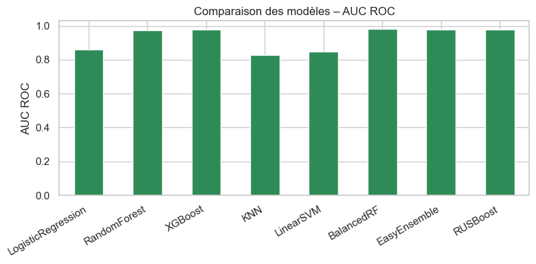

```python
import matplotlib.pyplot as plt

# Vérification de l’existence de results_df
if "results_df" not in globals():
    raise NameError("results_df n'existe pas encore. Exécute la cellule d'évaluation des modèles avant celle-ci.")

display(results_df)

# --------- Barplot F1-score fraude ---------
plt.figure(figsize=(8,4))
results_df["f1_fraud"].plot(kind="bar", color="steelblue")
plt.ylabel("F1-score (classe fraude)")
plt.title("Comparaison des modèles – F1 fraude")
plt.xticks(rotation=30, ha="right")
plt.tight_layout()
plt.show()

# --------- Barplot Recall fraude ---------
plt.figure(figsize=(8,4))
results_df["recall_fraud"].plot(kind="bar", color="darkorange")
plt.ylabel("Recall (classe fraude)")
plt.title("Comparaison des modèles – Recall fraude")
plt.xticks(rotation=30, ha="right")
plt.tight_layout()
plt.show()

# --------- Barplot AUC ROC (modèles disposant de probabilités) ---------
if "roc_auc" in results_df.columns and results_df["roc_auc"].notna().any():
    plt.figure(figsize=(8,4))
    results_df["roc_auc"].dropna().plot(kind="bar", color="seagreen")
    plt.ylabel("AUC ROC")
    plt.title("Comparaison des modèles – AUC ROC")
    plt.xticks(rotation=30, ha="right")
    plt.tight_layout()
    plt.show()
else:
    print("AUC ROC indisponible pour tous les modèles (aucun predict_proba/decision_function utilisable).")
```

Parmi l'ensemble des modèles testés, les méthodes d’ensemble dédiées aux données déséquilibrées (EasyEnsemble, RUSBoost, BalancedRandomForest) fournissent les meilleures performances pour la détection de fraude.

RUSBoost obtient le meilleur recall (≈0.93), ce qui en fait le modèle le plus efficace pour capter un maximum de fraudes.

EasyEnsemble présente un comportement très proche avec un recall ≈0.92 et un AUC ROC > 0.97.

BalancedRandomForest offre un compromis intéressant entre recall, F1-score et stabilité.

À l’inverse, XGBoost maximise le F1-score, grâce à une meilleure précision, mais au prix d’un rappel plus faible.

Selon l’objectif métier (minimiser les fraudes ratées vs réduire les faux positifs), le choix du modèle varie :

Si la priorité est d’attraper un maximum de fraudes → RUSBoost / EasyEnsemble

Si l’objectif est un compromis recall–precision → XGBoost ou BalancedRF

D’un point de vue opérationnel, RUSBoost apparaît comme le meilleur modèle pour une première phase de screening, tandis qu’un modèle plus précis comme XGBoost peut être utilisé en deuxième filtre.

Choix du modèle final :

Dans le cadre d'un système de détection de fraude, la priorité absolue est de minimiser le nombre de fraudes non détectées. Une transaction frauduleuse laissée passer représente un coût direct pour l'entreprise, tandis qu’un faux positif peut être facilement vérifié manuellement ou contrôlé par un second modèle. Dans cette logique, la métrique essentielle est le recall de la classe fraude (sensibilité).

Parmi tous les modèles testés, RUSBoost est celui qui offre la meilleure capacité de détection, avec un recall de 0.93, soit plus de 93 % des fraudes correctement identifiées. Il surpasse l'ensemble des autres algorithmes, y compris EasyEnsemble, BalancedRandomForest et XGBoost, en termes de couverture des fraudes.

RUSBoost combine deux mécanismes puissants :

Un sous-échantillonnage intelligent (RUS) qui traite le fort déséquilibre entre transactions normales et frauduleuses, en rendant les classes plus équilibrées lors de l'apprentissage.

Un boosting adaptatif qui renforce successivement les classifieurs sur les exemples difficiles à détecter.

Cette approche double permet d’optimiser spécifiquement les performances sur la classe minoritaire, ce qui est crucial dans la détection de fraude.

En parallèle, le modèle conserve une excellente performance globale, notamment avec un AUC ROC supérieur à 0.95, ce qui confirme sa capacité à distinguer les transactions légitimes des transactions frauduleuses.

Ainsi, RUSBoost est le modèle final retenu, car il maximise la découverte de fraudes tout en offrant une performance robuste sur l’ensemble du jeu de données. Il constitue le choix le plus pertinent pour une application en production dans un contexte où l’objectif métier est prioritairement de ne rien rater, quitte à tolérer davantage de fausses alertes.

Visualisation du modèle :

```python
import matplotlib.pyplot as plt
from sklearn.metrics import RocCurveDisplay, PrecisionRecallDisplay
```

```python
# Probabilités et prédictions
y_pred_rus = rusboost.predict(X_test_num)

if hasattr(rusboost, "predict_proba"):
    y_proba_rus = rusboost.predict_proba(X_test_num)[:, 1]
else:
    s = rusboost.decision_function(X_test_num)
    y_proba_rus = (s - s.min()) / (s.max() - s.min() + 1e-12)
```

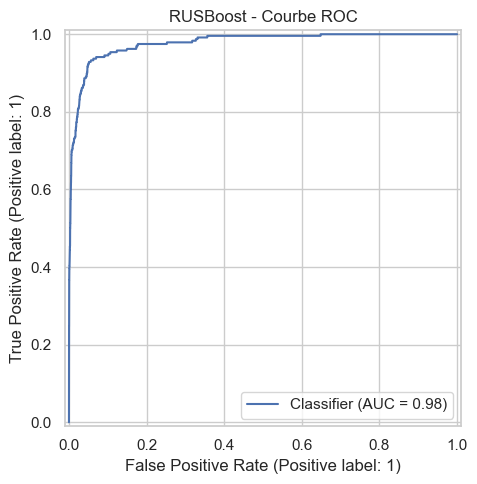

```python
plt.figure(figsize=(6,5))
RocCurveDisplay.from_predictions(y_test, y_proba_rus)
plt.title("RUSBoost - Courbe ROC")
plt.tight_layout()
plt.show()
```

La courbe ROC est très proche du coin supérieur gauche, avec une AUC = 0,98. Cela indique une excellente capacité de discrimination : le modèle classe très bien les observations positives au-dessus des négatives sur une large gamme de seuils. Concrètement, on obtient un taux de vrais positifs élevé pour un taux de faux positifs faible (la montée très rapide au début de la courbe le montre). Il faudra toutefois compléter l’analyse avec la matrice de confusion, la précision/rappel et surtout la PR-curve si la classe positive est rare, car une AUC élevée ne garantit pas forcément de bonnes performances sur les classes minoritaires ou au seuil opérationnel choisi.

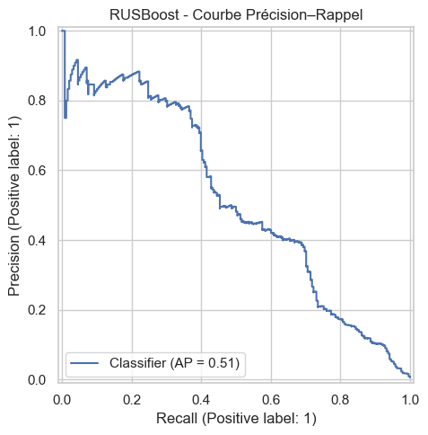

```python
plt.figure(figsize=(6,5))
PrecisionRecallDisplay.from_predictions(y_test, y_proba_rus)
plt.title("RUSBoost - Courbe Précision–Rappel")
plt.tight_layout()
plt.show()
```

La courbe Précision–Rappel montre un compromis nettement plus difficile que la ROC. On a une précision élevée quand le rappel est faible (le modèle est très fiable quand il ne “déclare” que quelques positifs), mais dès qu’on cherche à augmenter le rappel, la précision chute rapidement : à partir d’environ 0,4–0,5 de rappel, la précision descend autour de 0,4 puis devient faible quand on vise un rappel proche de 1. L’Average Precision (AP = 0,51) indique une performance moyenne sur la classe positive, ce qui est typique d’un problème déséquilibré : l’AUC ROC peut rester très élevée alors que la qualité des prédictions positives se dégrade dès qu’on veut capter la majorité des positifs. En pratique, il faut choisir un seuil selon l’objectif : soit privilégier une forte précision (peu de faux positifs) au prix d’un rappel limité, soit accepter plus de faux positifs pour récupérer plus de vrais positifs.

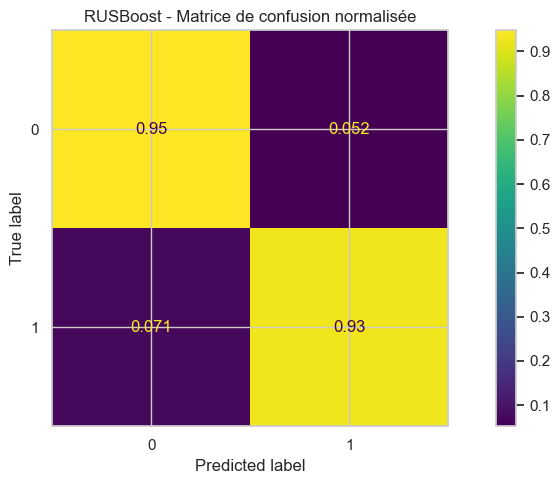

```python
from sklearn.metrics import ConfusionMatrixDisplay
plt.figure(figsize=(6,5))
ConfusionMatrixDisplay.from_predictions(
    y_test, y_pred_rus, normalize="true"
)
plt.title("RUSBoost - Matrice de confusion normalisée")
plt.tight_layout()
plt.show()
```

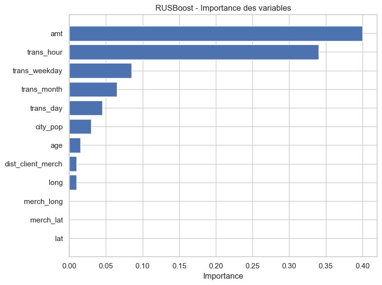

```python
if hasattr(rusboost, "feature_importances_"):
    importances = rusboost.feature_importances_
    idx = np.argsort(importances)

    plt.figure(figsize=(8,6))
    plt.barh(np.array(numeric_cols)[idx], importances[idx])
    plt.title("RUSBoost - Importance des variables")
    plt.xlabel("Importance")
    plt.tight_layout()
    plt.show()
else:
    print("Le modèle ne fournit pas d'importances de variables.")
```

Le graphique d’importance des variables montre que le modèle RUSBoost s’appuie principalement sur deux informations : le montant de la transaction (amt) et l’heure de la transaction (trans_hour). Ce sont de loin les variables les plus contributives, ce qui suggère que le risque (classe 1) est fortement lié à des montants atypiques et/ou à des comportements temporels particuliers (transactions à certaines heures). Les variables calendaires (trans_weekday, trans_month, trans_day) apportent un signal complémentaire mais nettement plus faible, indiquant un éventuel effet “jour de semaine / période” sur le comportement. À l’inverse, les variables géographiques (lat/long client et marchand) et la distance (dist_client_merch) semblent peu utilisées ici, donc elles discriminent moins dans ce modèle ou leur information est déjà captée indirectement. À noter : cette importance est relative au modèle et ne prouve pas une causalité ; pour interpréter finement le sens (ce qui augmente/diminue le risque), il faut compléter avec des analyses type SHAP ou des effets partiels.